# FISAC - Data Analytics (DSE 2121)

### Name: Keerthan Kumar C

Registration Number: 220968002

Branch: Data Science and Engineering

Semster: IIIrd Sem

Section and Batch: B Section Batch B1

Subject: Data Analytics

### Objective:

Perform the analysis on the given dataset and write the observed insights about the relationship between the market value and the following categories:

Position

Country

Age

Club

Players

Also, compare the two most valuable players based on various parameters.

# MetaData

## Dataset Name: Most Expensive Footballers 2021

### Description:

This dataset encompasses statistical data of football players, detailing their performance and attributes across different countries and clubs.

### Columns:

1. `Name` - Player's name (string)
2. `Position` - Player's position on the field (string)
3. `Age` - Player's age (integer)
4. `Market_value` - Estimated market value of the player (float)
5. `Country` - Country where the player is active (string)
6. `Club` - Football club the player belongs to (string)
7. `Matches` - Total matches played by the player (integer)
8. `Goals` - Total goals scored by the player (integer)
9. `Own_goals` - Number of own goals scored by the player (integer)
10. `Assists` - Total assists provided by the player (integer)
11. `Yellow_cards` - Total yellow cards received by the player (integer)
12. `Second_yellow_cards` - Total second yellow cards received by the player (integer)
13. `Red_cards` - Total red cards received by the player (integer)
14. `Substitute_in` - Number of times the player was substituted in (integer)
15. `Substitute_out` - Number of times the player was substituted out (integer)

### Data Types:

- `Name`: String
- `Position`: String
- `Age`: Integer
- `Market_value`: Float
- `Country`: String
- `Club`: String
- `Matches`: Integer
- `Goals`: Integer
- `Own_goals`: Integer
- `Assists`: Integer
- `Yellow_cards`: Integer
- `Second_yellow_cards`: Integer
- `Red_cards`: Integer
- `Substitute_in`: Integer
- `Substitute_out`: Integer

### Notes:

- The dataset contains 500 entries for various football players.
- 'Position' denotes the player's specific role on the field (e.g., Forward, Midfielder, Defender, Goalkeeper, etc.).
- 'Market_value' provides an estimated value of the player in the football market.
- The dataset contains no missing values (all columns have 500 non-null entries).
- Ensure consistency in data recording and categorization for accurate analysis across countries and clubs.

# 1. Loading the libraries and reading the csv

```python
# importing libraries
import pandas as pd
import numpy as np
import seaborn as sns
import matplotlib.pyplot as plt
from mlxtend.frequent_patterns import apriori, association_rules
from mlxtend.preprocessing import TransactionEncoder
```

```python
#reading csv file
df=pd.read_csv("players.csv")
df
```

|  | Unnamed: 0 | Name | Position | Age | Markey Value In Millions(£) | Country | Club | Matches | Goals | Own Goals | Assists | Yellow Cards | Second Yellow Cards | Red Cards | Number Of Substitute In | Number Of Substitute Out |
| --- | --- | --- | --- | --- | --- | --- | --- | --- | --- | --- | --- | --- | --- | --- | --- | --- |
| 0 | 0 | Kylian Mbappé | Centre-Forward | 22 | 144.0 | France | Paris Saint-Germain | 16 | 7 | 0 | 11 | 3 | 0 | 0 | 0 | 8 |
| 1 | 1 | Erling Haaland | Centre-Forward | 21 | 135.0 | Norway | Borussia Dortmund | 10 | 13 | 0 | 4 | 1 | 0 | 0 | 0 | 1 |
| 2 | 2 | Harry Kane | Centre-Forward | 28 | 108.0 | England | Tottenham Hotspur | 16 | 7 | 0 | 2 | 2 | 0 | 0 | 2 | 2 |
| 3 | 3 | Jack Grealish | Left Winger | 26 | 90.0 | England | Manchester City | 15 | 2 | 0 | 3 | 1 | 0 | 0 | 2 | 8 |
| 4 | 4 | Mohamed Salah | Right Winger | 29 | 90.0 | Egypt | Liverpool FC | 15 | 15 | 0 | 6 | 1 | 0 | 0 | 0 | 3 |
| ... | ... | ... | ... | ... | ... | ... | ... | ... | ... | ... | ... | ... | ... | ... | ... | ... |
| 495 | 495 | Giorgian de Arrascaeta | Attacking Midfield | 27 | 16.2 | Uruguay | Clube de Regatas do Flamengo | 0 | 0 | 0 | 0 | 0 | 0 | 0 | 0 | 0 |
| 496 | 496 | Ayoze Pérez | Second Striker | 28 | 16.2 | Spain | Leicester City | 8 | 1 | 0 | 3 | 0 | 0 | 1 | 2 | 5 |
| 497 | 497 | Alex Meret | Goalkeeper | 24 | 16.2 | Italy | SSC Napoli | 5 | 0 | 0 | 0 | 0 | 0 | 0 | 0 | 0 |
| 498 | 498 | Duje Caleta-Car | Centre-Back | 25 | 16.2 | Croatia | Olympique Marseille | 8 | 0 | 0 | 0 | 2 | 0 | 0 | 0 | 2 |
| 499 | 499 | Aritz Elustondo | Centre-Back | 27 | 16.2 | Spain | Real Sociedad | 15 | 3 | 0 | 1 | 4 | 0 | 0 | 1 | 1 |

500 rows × 16 columns

# 2. Exploratory Analysis

```python
df.head()
```

|  | Unnamed: 0 | Name | Position | Age | Markey Value In Millions(£) | Country | Club | Matches | Goals | Own Goals | Assists | Yellow Cards | Second Yellow Cards | Red Cards | Number Of Substitute In | Number Of Substitute Out |
| --- | --- | --- | --- | --- | --- | --- | --- | --- | --- | --- | --- | --- | --- | --- | --- | --- |
| 0 | 0 | Kylian Mbappé | Centre-Forward | 22 | 144.0 | France | Paris Saint-Germain | 16 | 7 | 0 | 11 | 3 | 0 | 0 | 0 | 8 |
| 1 | 1 | Erling Haaland | Centre-Forward | 21 | 135.0 | Norway | Borussia Dortmund | 10 | 13 | 0 | 4 | 1 | 0 | 0 | 0 | 1 |
| 2 | 2 | Harry Kane | Centre-Forward | 28 | 108.0 | England | Tottenham Hotspur | 16 | 7 | 0 | 2 | 2 | 0 | 0 | 2 | 2 |
| 3 | 3 | Jack Grealish | Left Winger | 26 | 90.0 | England | Manchester City | 15 | 2 | 0 | 3 | 1 | 0 | 0 | 2 | 8 |
| 4 | 4 | Mohamed Salah | Right Winger | 29 | 90.0 | Egypt | Liverpool FC | 15 | 15 | 0 | 6 | 1 | 0 | 0 | 0 | 3 |

```python
df.tail()
```

|  | Unnamed: 0 | Name | Position | Age | Markey Value In Millions(£) | Country | Club | Matches | Goals | Own Goals | Assists | Yellow Cards | Second Yellow Cards | Red Cards | Number Of Substitute In | Number Of Substitute Out |
| --- | --- | --- | --- | --- | --- | --- | --- | --- | --- | --- | --- | --- | --- | --- | --- | --- |
| 495 | 495 | Giorgian de Arrascaeta | Attacking Midfield | 27 | 16.2 | Uruguay | Clube de Regatas do Flamengo | 0 | 0 | 0 | 0 | 0 | 0 | 0 | 0 | 0 |
| 496 | 496 | Ayoze Pérez | Second Striker | 28 | 16.2 | Spain | Leicester City | 8 | 1 | 0 | 3 | 0 | 0 | 1 | 2 | 5 |
| 497 | 497 | Alex Meret | Goalkeeper | 24 | 16.2 | Italy | SSC Napoli | 5 | 0 | 0 | 0 | 0 | 0 | 0 | 0 | 0 |
| 498 | 498 | Duje Caleta-Car | Centre-Back | 25 | 16.2 | Croatia | Olympique Marseille | 8 | 0 | 0 | 0 | 2 | 0 | 0 | 0 | 2 |
| 499 | 499 | Aritz Elustondo | Centre-Back | 27 | 16.2 | Spain | Real Sociedad | 15 | 3 | 0 | 1 | 4 | 0 | 0 | 1 | 1 |

```python
#removing the unnamed columns
df.drop(columns="Unnamed: 0",axis=1,inplace=True)
df
```

|  | Name | Position | Age | Markey Value In Millions(£) | Country | Club | Matches | Goals | Own Goals | Assists | Yellow Cards | Second Yellow Cards | Red Cards | Number Of Substitute In | Number Of Substitute Out |
| --- | --- | --- | --- | --- | --- | --- | --- | --- | --- | --- | --- | --- | --- | --- | --- |
| 0 | Kylian Mbappé | Centre-Forward | 22 | 144.0 | France | Paris Saint-Germain | 16 | 7 | 0 | 11 | 3 | 0 | 0 | 0 | 8 |
| 1 | Erling Haaland | Centre-Forward | 21 | 135.0 | Norway | Borussia Dortmund | 10 | 13 | 0 | 4 | 1 | 0 | 0 | 0 | 1 |
| 2 | Harry Kane | Centre-Forward | 28 | 108.0 | England | Tottenham Hotspur | 16 | 7 | 0 | 2 | 2 | 0 | 0 | 2 | 2 |
| 3 | Jack Grealish | Left Winger | 26 | 90.0 | England | Manchester City | 15 | 2 | 0 | 3 | 1 | 0 | 0 | 2 | 8 |
| 4 | Mohamed Salah | Right Winger | 29 | 90.0 | Egypt | Liverpool FC | 15 | 15 | 0 | 6 | 1 | 0 | 0 | 0 | 3 |
| ... | ... | ... | ... | ... | ... | ... | ... | ... | ... | ... | ... | ... | ... | ... | ... |
| 495 | Giorgian de Arrascaeta | Attacking Midfield | 27 | 16.2 | Uruguay | Clube de Regatas do Flamengo | 0 | 0 | 0 | 0 | 0 | 0 | 0 | 0 | 0 |
| 496 | Ayoze Pérez | Second Striker | 28 | 16.2 | Spain | Leicester City | 8 | 1 | 0 | 3 | 0 | 0 | 1 | 2 | 5 |
| 497 | Alex Meret | Goalkeeper | 24 | 16.2 | Italy | SSC Napoli | 5 | 0 | 0 | 0 | 0 | 0 | 0 | 0 | 0 |
| 498 | Duje Caleta-Car | Centre-Back | 25 | 16.2 | Croatia | Olympique Marseille | 8 | 0 | 0 | 0 | 2 | 0 | 0 | 0 | 2 |
| 499 | Aritz Elustondo | Centre-Back | 27 | 16.2 | Spain | Real Sociedad | 15 | 3 | 0 | 1 | 4 | 0 | 0 | 1 | 1 |

500 rows × 15 columns

```python
#renaming some columns for better use
df = df.rename(columns=
            {'Markey Value In Millions(£)': 'Market_value','Own Goals': 'Own_goals',
             'Yellow Cards': 'Yellow_cards','Second Yellow Cards': 'Second_yellow_cards',
             'Red Cards': 'Red_cards', 'Number Of Substitute In': 'Substitute_in',
             'Number Of Substitute Out': 'Substitute_out'})
df
```

|  | Name | Position | Age | Market_value | Country | Club | Matches | Goals | Own_goals | Assists | Yellow_cards | Second_yellow_cards | Red_cards | Substitute_in | Substitute_out |
| --- | --- | --- | --- | --- | --- | --- | --- | --- | --- | --- | --- | --- | --- | --- | --- |
| 0 | Kylian Mbappé | Centre-Forward | 22 | 144.0 | France | Paris Saint-Germain | 16 | 7 | 0 | 11 | 3 | 0 | 0 | 0 | 8 |
| 1 | Erling Haaland | Centre-Forward | 21 | 135.0 | Norway | Borussia Dortmund | 10 | 13 | 0 | 4 | 1 | 0 | 0 | 0 | 1 |
| 2 | Harry Kane | Centre-Forward | 28 | 108.0 | England | Tottenham Hotspur | 16 | 7 | 0 | 2 | 2 | 0 | 0 | 2 | 2 |
| 3 | Jack Grealish | Left Winger | 26 | 90.0 | England | Manchester City | 15 | 2 | 0 | 3 | 1 | 0 | 0 | 2 | 8 |
| 4 | Mohamed Salah | Right Winger | 29 | 90.0 | Egypt | Liverpool FC | 15 | 15 | 0 | 6 | 1 | 0 | 0 | 0 | 3 |
| ... | ... | ... | ... | ... | ... | ... | ... | ... | ... | ... | ... | ... | ... | ... | ... |
| 495 | Giorgian de Arrascaeta | Attacking Midfield | 27 | 16.2 | Uruguay | Clube de Regatas do Flamengo | 0 | 0 | 0 | 0 | 0 | 0 | 0 | 0 | 0 |
| 496 | Ayoze Pérez | Second Striker | 28 | 16.2 | Spain | Leicester City | 8 | 1 | 0 | 3 | 0 | 0 | 1 | 2 | 5 |
| 497 | Alex Meret | Goalkeeper | 24 | 16.2 | Italy | SSC Napoli | 5 | 0 | 0 | 0 | 0 | 0 | 0 | 0 | 0 |
| 498 | Duje Caleta-Car | Centre-Back | 25 | 16.2 | Croatia | Olympique Marseille | 8 | 0 | 0 | 0 | 2 | 0 | 0 | 0 | 2 |
| 499 | Aritz Elustondo | Centre-Back | 27 | 16.2 | Spain | Real Sociedad | 15 | 3 | 0 | 1 | 4 | 0 | 0 | 1 | 1 |

500 rows × 15 columns

```python
df.info()
```

```
<class 'pandas.core.frame.DataFrame'>
RangeIndex: 500 entries, 0 to 499
Data columns (total 15 columns):
 #   Column               Non-Null Count  Dtype
---  ------               --------------  -----
 0   Name                 500 non-null    object
 1   Position             500 non-null    object
 2   Age                  500 non-null    int64
 3   Market_value         500 non-null    float64
 4   Country              500 non-null    object
 5   Club                 500 non-null    object
 6   Matches              500 non-null    int64
 7   Goals                500 non-null    int64
 8   Own_goals            500 non-null    int64
 9   Assists              500 non-null    int64
 10  Yellow_cards         500 non-null    int64
 11  Second_yellow_cards  500 non-null    int64
 12  Red_cards            500 non-null    int64
 13  Substitute_in        500 non-null    int64
 14  Substitute_out       500 non-null    int64
dtypes: float64(1), int64(10), object(4)
memory usage: 58.7+ KB
```

```python
df.dtypes
```

```
Name                    object
Position                object
Age                      int64
Market_value           float64
Country                 object
Club                    object
Matches                  int64
Goals                    int64
Own_goals                int64
Assists                  int64
Yellow_cards             int64
Second_yellow_cards      int64
Red_cards                int64
Substitute_in            int64
Substitute_out           int64
dtype: object
```

```python
#checking for any null values
df.isna().sum()
```

```
Name                   0
Position               0
Age                    0
Market_value           0
Country                0
Club                   0
Matches                0
Goals                  0
Own_goals              0
Assists                0
Yellow_cards           0
Second_yellow_cards    0
Red_cards              0
Substitute_in          0
Substitute_out         0
dtype: int64
```

```python
#descriptive statistics of the dataset
df.describe()
```

|  | Age | Market_value | Matches | Goals | Own_goals | Assists | Yellow_cards | Second_yellow_cards | Red_cards | Substitute_in | Substitute_out |
| --- | --- | --- | --- | --- | --- | --- | --- | --- | --- | --- | --- |
| count | 500.000000 | 500.000000 | 500.000000 | 500.000000 | 500.000000 | 500.00000 | 500.000000 | 500.000000 | 500.000000 | 500.000000 | 500.000000 |
| mean | 24.968000 | 31.537800 | 12.396000 | 2.160000 | 0.030000 | 1.51200 | 1.592000 | 0.036000 | 0.046000 | 2.394000 | 3.744000 |
| std | 3.165916 | 17.577697 | 4.342453 | 2.880102 | 0.170758 | 1.85276 | 1.445585 | 0.186477 | 0.209695 | 2.517825 | 3.293046 |
| min | 16.000000 | 16.200000 | 0.000000 | 0.000000 | 0.000000 | 0.00000 | 0.000000 | 0.000000 | 0.000000 | 0.000000 | 0.000000 |
| 25% | 23.000000 | 19.800000 | 10.000000 | 0.000000 | 0.000000 | 0.00000 | 0.000000 | 0.000000 | 0.000000 | 0.000000 | 1.000000 |
| 50% | 25.000000 | 25.200000 | 13.000000 | 1.000000 | 0.000000 | 1.00000 | 1.000000 | 0.000000 | 0.000000 | 2.000000 | 3.000000 |
| 75% | 27.000000 | 36.000000 | 16.000000 | 3.000000 | 0.000000 | 2.00000 | 2.000000 | 0.000000 | 0.000000 | 3.250000 | 6.000000 |
| max | 36.000000 | 144.000000 | 24.000000 | 23.000000 | 1.000000 | 12.00000 | 7.000000 | 1.000000 | 1.000000 | 13.000000 | 20.000000 |

```python
df.shape
```

```
(500, 15)
```

```python
df['Club'].unique()
```

```
array(['Paris Saint-Germain', 'Borussia Dortmund', 'Tottenham Hotspur',
       'Manchester City', 'Liverpool FC', 'Chelsea FC',
       'Manchester United', 'FC Barcelona', 'Bayern Munich',
       'Inter Milan', 'Atlético de Madrid', 'West Ham United',
       'Real Sociedad', 'Juventus FC', 'SS Lazio', 'Real Madrid',
       'Bayer 04 Leverkusen', 'Arsenal FC', 'Sevilla FC', 'SSC Napoli',
       'Leicester City', 'Everton FC', 'AC Milan', 'Villarreal CF',
       'ACF Fiorentina', 'RB Leipzig', 'AS Roma', 'Crystal Palace',
       'Wolverhampton Wanderers', 'Valencia CF', 'Leeds United',
       'LOSC Lille', 'Aston Villa', 'Olympique Lyon', 'OGC Nice',
       'AS Monaco', 'Atalanta BC', 'US Sassuolo', 'Torino FC',
       'Ajax Amsterdam', 'Brentford FC', 'Southampton FC',
       'Newcastle United', 'VfL Wolfsburg', 'FC Porto',
       'Olympique Marseille', 'Eintracht Frankfurt',
       'Borussia Mönchengladbach', 'Watford FC', 'Stade Rennais FC',
       'Clube de Regatas do Flamengo', 'VfB Stuttgart', 'Club Brugge KV',
       'Sporting CP', 'Brighton & Hove Albion', 'Dynamo Kyiv',
       'Athletic Bilbao', 'Real Betis Balompié', 'Zenit St. Petersburg',
       'Burnley FC', 'SL Benfica', 'TSG 1899 Hoffenheim', 'Norwich City',
       'PSV Eindhoven', 'KRC Genk', 'Club Atlético Vélez Sarsfield',
       'Club Atlético River Plate', 'FC Metz', 'UC Sampdoria',
       'Red Bull Salzburg', 'Bologna FC 1909', 'Shakhtar Donetsk',
       'Cagliari Calcio', 'Getafe CF', 'Al-Rayyan SC', 'Rubin Kazan',
       'Feyenoord Rotterdam', 'RCD Espanyol Barcelona', 'UD Almería',
       'Sheffield United', 'Celta de Vigo'], dtype=object)
```

```python
df['Club'].nunique()
```

```
81
```

```python
df.Country.unique()
```

```
array(['France', 'Norway', 'England', 'Egypt', 'Belgium', 'Brazil',
       'Netherlands', 'Portugal', 'Germany', 'Senegal', 'Korea, South',
       'Spain', 'Argentina', 'Canada', 'Morocco', 'Italy', 'Serbia',
       'Slovenia', 'Uruguay', 'Scotland', 'Nigeria', 'Slovakia', 'Poland',
       "Cote d'Ivoire", 'Austria', 'United States', 'Turkey', 'Mexico',
       'Croatia', 'Czech Republic', 'Algeria', 'Burkina Faso', 'Sweden',
       'Ghana', 'Denmark', 'Jamaica', 'Colombia', 'Guinea', 'Switzerland',
       'Ukraine', 'Russia', 'DR Congo', 'Hungary', 'Mali', 'Japan',
       'Cameroon', 'Iran', 'Montenegro', 'Gabon', 'Albania', 'Zambia',
       'The Gambia', 'Israel', 'Georgia', 'Venezuela', 'Wales', 'Peru'],
      dtype=object)
```

```python
df.Country.nunique()
```

```
57
```

```python
df.Position.unique()
```

```
array(['Centre-Forward', 'Left Winger', 'Right Winger',
       'Attacking Midfield', 'Central Midfield', 'Defensive Midfield',
       'Right-Back', 'Centre-Back', 'Second Striker', 'Left-Back',
       'Goalkeeper', 'Left Midfield', 'Right Midfield'], dtype=object)
```

```python
df.Position.nunique()
```

```
13
```

```python
# Creating new categories for Position into 3 categories(attacker,midfielder,defender,goalkeeper)

df['New_Position'] = np.where((df['Position'] == 'Centre-Forward') |
                                (df['Position'] == 'Left Winger') |
                                (df['Position'] == 'Right Winger')|
                                (df['Position'] == 'Second Striker'),'Attacker',
                                np.where((df['Position'] == 'Attacking Midfield') |
                                         (df['Position'] == 'Central Midfield') |
                                         (df['Position'] == 'Defensive Midfield') |
                                         (df['Position'] == 'Left Midfield') |
                                         (df['Position'] == 'Right Midfield'), 'Midfielder',
                                         np.where(df['Position'] == 'Goalkeeper',
                                                  'Goalkeeper','Defender')))
df
```

|  | Name | Position | Age | Market_value | Country | Club | Matches | Goals | Own_goals | Assists | Yellow_cards | Second_yellow_cards | Red_cards | Substitute_in | Substitute_out | New_Position |
| --- | --- | --- | --- | --- | --- | --- | --- | --- | --- | --- | --- | --- | --- | --- | --- | --- |
| 0 | Kylian Mbappé | Centre-Forward | 22 | 144.0 | France | Paris Saint-Germain | 16 | 7 | 0 | 11 | 3 | 0 | 0 | 0 | 8 | Attacker |
| 1 | Erling Haaland | Centre-Forward | 21 | 135.0 | Norway | Borussia Dortmund | 10 | 13 | 0 | 4 | 1 | 0 | 0 | 0 | 1 | Attacker |
| 2 | Harry Kane | Centre-Forward | 28 | 108.0 | England | Tottenham Hotspur | 16 | 7 | 0 | 2 | 2 | 0 | 0 | 2 | 2 | Attacker |
| 3 | Jack Grealish | Left Winger | 26 | 90.0 | England | Manchester City | 15 | 2 | 0 | 3 | 1 | 0 | 0 | 2 | 8 | Attacker |
| 4 | Mohamed Salah | Right Winger | 29 | 90.0 | Egypt | Liverpool FC | 15 | 15 | 0 | 6 | 1 | 0 | 0 | 0 | 3 | Attacker |
| ... | ... | ... | ... | ... | ... | ... | ... | ... | ... | ... | ... | ... | ... | ... | ... | ... |
| 495 | Giorgian de Arrascaeta | Attacking Midfield | 27 | 16.2 | Uruguay | Clube de Regatas do Flamengo | 0 | 0 | 0 | 0 | 0 | 0 | 0 | 0 | 0 | Midfielder |
| 496 | Ayoze Pérez | Second Striker | 28 | 16.2 | Spain | Leicester City | 8 | 1 | 0 | 3 | 0 | 0 | 1 | 2 | 5 | Attacker |
| 497 | Alex Meret | Goalkeeper | 24 | 16.2 | Italy | SSC Napoli | 5 | 0 | 0 | 0 | 0 | 0 | 0 | 0 | 0 | Goalkeeper |
| 498 | Duje Caleta-Car | Centre-Back | 25 | 16.2 | Croatia | Olympique Marseille | 8 | 0 | 0 | 0 | 2 | 0 | 0 | 0 | 2 | Defender |
| 499 | Aritz Elustondo | Centre-Back | 27 | 16.2 | Spain | Real Sociedad | 15 | 3 | 0 | 1 | 4 | 0 | 0 | 1 | 1 | Defender |

500 rows × 16 columns

```python
# converting Market_value from float to int

df['Market_value'] = df['Market_value'].astype(int)
df.Market_value.dtype
```

```
dtype('int32')
```

```python
# creating new columns

df['Goals.per.game'] =  (df['Goals']/df['Matches']).round(2)
df['Assists.per.game'] =  (df['Assists']/df['Matches']).round(2)
df
```

|  | Name | Position | Age | Market_value | Country | Club | Matches | Goals | Own_goals | Assists | Yellow_cards | Second_yellow_cards | Red_cards | Substitute_in | Substitute_out | New_Position | Goals.per.game | Assists.per.game |
| --- | --- | --- | --- | --- | --- | --- | --- | --- | --- | --- | --- | --- | --- | --- | --- | --- | --- | --- |
| 0 | Kylian Mbappé | Centre-Forward | 22 | 144 | France | Paris Saint-Germain | 16 | 7 | 0 | 11 | 3 | 0 | 0 | 0 | 8 | Attacker | 0.44 | 0.69 |
| 1 | Erling Haaland | Centre-Forward | 21 | 135 | Norway | Borussia Dortmund | 10 | 13 | 0 | 4 | 1 | 0 | 0 | 0 | 1 | Attacker | 1.30 | 0.40 |
| 2 | Harry Kane | Centre-Forward | 28 | 108 | England | Tottenham Hotspur | 16 | 7 | 0 | 2 | 2 | 0 | 0 | 2 | 2 | Attacker | 0.44 | 0.12 |
| 3 | Jack Grealish | Left Winger | 26 | 90 | England | Manchester City | 15 | 2 | 0 | 3 | 1 | 0 | 0 | 2 | 8 | Attacker | 0.13 | 0.20 |
| 4 | Mohamed Salah | Right Winger | 29 | 90 | Egypt | Liverpool FC | 15 | 15 | 0 | 6 | 1 | 0 | 0 | 0 | 3 | Attacker | 1.00 | 0.40 |
| ... | ... | ... | ... | ... | ... | ... | ... | ... | ... | ... | ... | ... | ... | ... | ... | ... | ... | ... |
| 495 | Giorgian de Arrascaeta | Attacking Midfield | 27 | 16 | Uruguay | Clube de Regatas do Flamengo | 0 | 0 | 0 | 0 | 0 | 0 | 0 | 0 | 0 | Midfielder | NaN | NaN |
| 496 | Ayoze Pérez | Second Striker | 28 | 16 | Spain | Leicester City | 8 | 1 | 0 | 3 | 0 | 0 | 1 | 2 | 5 | Attacker | 0.12 | 0.38 |
| 497 | Alex Meret | Goalkeeper | 24 | 16 | Italy | SSC Napoli | 5 | 0 | 0 | 0 | 0 | 0 | 0 | 0 | 0 | Goalkeeper | 0.00 | 0.00 |
| 498 | Duje Caleta-Car | Centre-Back | 25 | 16 | Croatia | Olympique Marseille | 8 | 0 | 0 | 0 | 2 | 0 | 0 | 0 | 2 | Defender | 0.00 | 0.00 |
| 499 | Aritz Elustondo | Centre-Back | 27 | 16 | Spain | Real Sociedad | 15 | 3 | 0 | 1 | 4 | 0 | 0 | 1 | 1 | Defender | 0.20 | 0.07 |

500 rows × 18 columns

```python
df.isna().sum()
```

```
Name                   0
Position               0
Age                    0
Market_value           0
Country                0
Club                   0
Matches                0
Goals                  0
Own_goals              0
Assists                0
Yellow_cards           0
Second_yellow_cards    0
Red_cards              0
Substitute_in          0
Substitute_out         0
New_Position           0
Goals.per.game         7
Assists.per.game       7
dtype: int64
```

```python
df.dropna(inplace=True)
df
```

|  | Name | Position | Age | Market_value | Country | Club | Matches | Goals | Own_goals | Assists | Yellow_cards | Second_yellow_cards | Red_cards | Substitute_in | Substitute_out | New_Position | Goals.per.game | Assists.per.game |
| --- | --- | --- | --- | --- | --- | --- | --- | --- | --- | --- | --- | --- | --- | --- | --- | --- | --- | --- |
| 0 | Kylian Mbappé | Centre-Forward | 22 | 144 | France | Paris Saint-Germain | 16 | 7 | 0 | 11 | 3 | 0 | 0 | 0 | 8 | Attacker | 0.44 | 0.69 |
| 1 | Erling Haaland | Centre-Forward | 21 | 135 | Norway | Borussia Dortmund | 10 | 13 | 0 | 4 | 1 | 0 | 0 | 0 | 1 | Attacker | 1.30 | 0.40 |
| 2 | Harry Kane | Centre-Forward | 28 | 108 | England | Tottenham Hotspur | 16 | 7 | 0 | 2 | 2 | 0 | 0 | 2 | 2 | Attacker | 0.44 | 0.12 |
| 3 | Jack Grealish | Left Winger | 26 | 90 | England | Manchester City | 15 | 2 | 0 | 3 | 1 | 0 | 0 | 2 | 8 | Attacker | 0.13 | 0.20 |
| 4 | Mohamed Salah | Right Winger | 29 | 90 | Egypt | Liverpool FC | 15 | 15 | 0 | 6 | 1 | 0 | 0 | 0 | 3 | Attacker | 1.00 | 0.40 |
| ... | ... | ... | ... | ... | ... | ... | ... | ... | ... | ... | ... | ... | ... | ... | ... | ... | ... | ... |
| 494 | Adam Armstrong | Centre-Forward | 24 | 16 | England | Southampton FC | 11 | 2 | 0 | 2 | 0 | 0 | 0 | 1 | 2 | Attacker | 0.18 | 0.18 |
| 496 | Ayoze Pérez | Second Striker | 28 | 16 | Spain | Leicester City | 8 | 1 | 0 | 3 | 0 | 0 | 1 | 2 | 5 | Attacker | 0.12 | 0.38 |
| 497 | Alex Meret | Goalkeeper | 24 | 16 | Italy | SSC Napoli | 5 | 0 | 0 | 0 | 0 | 0 | 0 | 0 | 0 | Goalkeeper | 0.00 | 0.00 |
| 498 | Duje Caleta-Car | Centre-Back | 25 | 16 | Croatia | Olympique Marseille | 8 | 0 | 0 | 0 | 2 | 0 | 0 | 0 | 2 | Defender | 0.00 | 0.00 |
| 499 | Aritz Elustondo | Centre-Back | 27 | 16 | Spain | Real Sociedad | 15 | 3 | 0 | 1 | 4 | 0 | 0 | 1 | 1 | Defender | 0.20 | 0.07 |

493 rows × 18 columns

# 3 Analysing Relationships

#### 3.1 Analzing relationship between marketvalue and other continuous data like goals

```python
analysis=df.corr()
analysis["Market_value"].sort_values(ascending=False)
```

```
Market_value           1.000000
Assists                0.225424
Goals.per.game         0.224564
Goals                  0.209460
Assists.per.game       0.201473
Matches                0.103294
Age                    0.049173
Second_yellow_cards    0.040727
Red_cards             -0.000039
Yellow_cards          -0.002807
Substitute_out        -0.004813
Own_goals             -0.034190
Substitute_in         -0.091397
Name: Market_value, dtype: float64
```

so we see how Age,goals,assists and all have positive impact and red cards and all having negative impact

#### 3.2 Checking relation between market value and different countries whether the market value varies in countries using annova

```python
unique_countries = df['Country'].unique()
max_length = df.groupby('Country')['Market_value'].count().max()
df_country_market_values = pd.DataFrame(0.0, columns=unique_countries, index=range(max_length))
for country in unique_countries:
    market_values = df[df['Country'] == country]['Market_value']
    df_country_market_values.loc[:len(market_values) - 1, country] = market_values.values

print(df_country_market_values)
```

```
    France  Norway  England  Egypt  Belgium  Brazil  Netherlands  Portugal  \
0    144.0   135.0    108.0   90.0     90.0    90.0         81.0      81.0
1     63.0    36.0     90.0    0.0     90.0    67.0         63.0      67.0
2     54.0    16.0     81.0    0.0     54.0    63.0         49.0      63.0
3     54.0     0.0     81.0    0.0     49.0    54.0         45.0      63.0
4     54.0     0.0     76.0    0.0     36.0    54.0         40.0      49.0
..     ...     ...      ...    ...      ...     ...          ...       ...
62     0.0     0.0     16.0    0.0      0.0     0.0          0.0       0.0
63     0.0     0.0     16.0    0.0      0.0     0.0          0.0       0.0
64     0.0     0.0     16.0    0.0      0.0     0.0          0.0       0.0
65     0.0     0.0     16.0    0.0      0.0     0.0          0.0       0.0
66     0.0     0.0     16.0    0.0      0.0     0.0          0.0       0.0

    Germany  Senegal  ...  Montenegro  Gabon  Albania  Zambia  The Gambia  \
0      81.0     76.0  ...        22.0   22.0     19.0    19.0        18.0
```

[output cut: 25 more lines]

```python
from scipy.stats import f_oneway

# Perform ANOVA
f_stat, p_value = f_oneway(*[df_country_market_values[country].dropna() for country in df_country_market_values.columns])
if p_value < 0.05:
    print("There are significant differences in market value among different countries,so analyzing based on countries is beneficial")
else:
    print("There might not be significant differences in market value among different countries.")
```

```
There are significant differences in market value among different countries,so analyzing based on countries is beneficial
```

#### 3.3 Checking relation between market value and different Positions whether the market value varies in Positions using annova

```python
unique_positions = df['Position'].unique()
positions_market_values = {position: [0.0] * len(df) for position in unique_positions}
df_positions_market_values = pd.DataFrame(positions_market_values, columns=unique_positions)

for position in unique_positions:
    market_values = df[df['Position'] == position]['Market_value']
    df_positions_market_values[position][:len(market_values)] = market_values.values

# Perform ANOVA
f_stat_pos, p_value_pos = f_oneway(*[df_positions_market_values[position].dropna() for position in df_positions_market_values.columns])

if p_value_pos < 0.05:
    print("There are significant differences in market value among different player positions,So it is beneficial to analyse based on positions")
else:
    print("There might not be significant differences in market value among different player positions.")
```

```
There are significant differences in market value among different player positions,So it is beneficial to analyse based on positions
```

#### 3.4 Checking relation between market value and different Clubs whether the market value varies in Positions using annova

```python
unique_clubs = df['Club'].unique()
clubs_market_values = {club: [0.0] * len(df) for club in unique_clubs}
df_clubs_market_values = pd.DataFrame(clubs_market_values, columns=unique_clubs)

# Assign market values to respective columns for each club
for club in unique_clubs:
    market_values = df[df['Club'] == club]['Market_value']
    df_clubs_market_values[club][:len(market_values)] = market_values.values

# Perform ANOVA
f_stat_clubs, p_value_clubs = f_oneway(*[df_clubs_market_values[club].dropna() for club in df_clubs_market_values.columns])

# Check for significance level (usually 0.05)
if p_value_clubs < 0.05:
    print("There are significant differences in market value among different clubs,So it is beneficial to analyse based on Different clubs")
else:
    print("There might not be significant differences in market value among different clubs.")
```

```
There are significant differences in market value among different clubs,So it is beneficial to analyse based on Different clubs
```

# 4. Market Value x Categories

## 4.1 Position

```python
df
```

|  | Name | Position | Age | Market_value | Country | Club | Matches | Goals | Own_goals | Assists | Yellow_cards | Second_yellow_cards | Red_cards | Substitute_in | Substitute_out | New_Position | Goals.per.game | Assists.per.game |
| --- | --- | --- | --- | --- | --- | --- | --- | --- | --- | --- | --- | --- | --- | --- | --- | --- | --- | --- |
| 0 | Kylian Mbappé | Centre-Forward | 22 | 144 | France | Paris Saint-Germain | 16 | 7 | 0 | 11 | 3 | 0 | 0 | 0 | 8 | Attacker | 0.44 | 0.69 |
| 1 | Erling Haaland | Centre-Forward | 21 | 135 | Norway | Borussia Dortmund | 10 | 13 | 0 | 4 | 1 | 0 | 0 | 0 | 1 | Attacker | 1.30 | 0.40 |
| 2 | Harry Kane | Centre-Forward | 28 | 108 | England | Tottenham Hotspur | 16 | 7 | 0 | 2 | 2 | 0 | 0 | 2 | 2 | Attacker | 0.44 | 0.12 |
| 3 | Jack Grealish | Left Winger | 26 | 90 | England | Manchester City | 15 | 2 | 0 | 3 | 1 | 0 | 0 | 2 | 8 | Attacker | 0.13 | 0.20 |
| 4 | Mohamed Salah | Right Winger | 29 | 90 | Egypt | Liverpool FC | 15 | 15 | 0 | 6 | 1 | 0 | 0 | 0 | 3 | Attacker | 1.00 | 0.40 |
| ... | ... | ... | ... | ... | ... | ... | ... | ... | ... | ... | ... | ... | ... | ... | ... | ... | ... | ... |
| 494 | Adam Armstrong | Centre-Forward | 24 | 16 | England | Southampton FC | 11 | 2 | 0 | 2 | 0 | 0 | 0 | 1 | 2 | Attacker | 0.18 | 0.18 |
| 496 | Ayoze Pérez | Second Striker | 28 | 16 | Spain | Leicester City | 8 | 1 | 0 | 3 | 0 | 0 | 1 | 2 | 5 | Attacker | 0.12 | 0.38 |
| 497 | Alex Meret | Goalkeeper | 24 | 16 | Italy | SSC Napoli | 5 | 0 | 0 | 0 | 0 | 0 | 0 | 0 | 0 | Goalkeeper | 0.00 | 0.00 |
| 498 | Duje Caleta-Car | Centre-Back | 25 | 16 | Croatia | Olympique Marseille | 8 | 0 | 0 | 0 | 2 | 0 | 0 | 0 | 2 | Defender | 0.00 | 0.00 |
| 499 | Aritz Elustondo | Centre-Back | 27 | 16 | Spain | Real Sociedad | 15 | 3 | 0 | 1 | 4 | 0 | 0 | 1 | 1 | Defender | 0.20 | 0.07 |

493 rows × 18 columns

```python
df["New_Position"].value_counts()
```

```
Attacker      170
Midfielder    166
Defender      138
Goalkeeper     19
Name: New_Position, dtype: int64
```

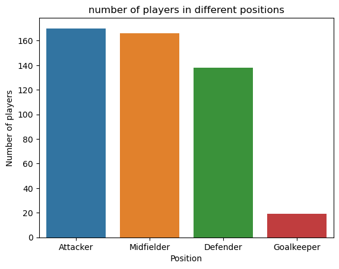

```python
#plotting the graph of number of players in different positions
sns.countplot(x="New_Position",data=df)
plt.title("number of players in different positions")
plt.xlabel("Position")
plt.ylabel("Number of players")
plt.show()
```

```python
df["Position"].value_counts()
```

```
Centre-Back           86
Central Midfield      74
Centre-Forward        69
Right Winger          48
Left Winger           45
Defensive Midfield    41
Attacking Midfield    39
Right-Back            30
Left-Back             22
Goalkeeper            19
Second Striker         8
Left Midfield          8
Right Midfield         4
Name: Position, dtype: int64
```

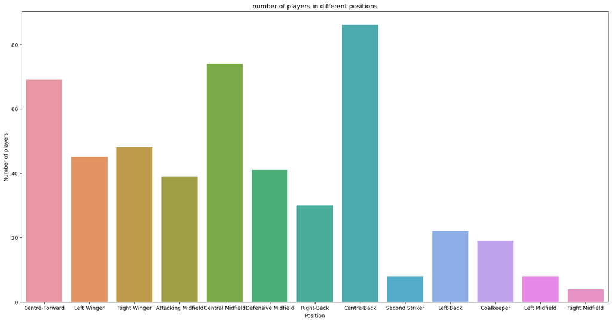

```python
#plotting the graph of number of players in different positions including all positions
plt.figure(figsize=(20,10))
sns.countplot(x="Position",data=df)
plt.title("number of players in different positions")
plt.xlabel("Position")
plt.ylabel("Number of players")
plt.show()
```

```python
position1=df.groupby(by="New_Position").Market_value.sum().reset_index(name="Market value based on positions")
position1.sort_values(by="Market value based on positions",ascending=False,inplace=True)
position1
```

|  | New_Position | Market value based on positions |
| --- | --- | --- |
| 0 | Attacker | 5652 |
| 3 | Midfielder | 5250 |
| 1 | Defender | 3972 |
| 2 | Goalkeeper | 582 |

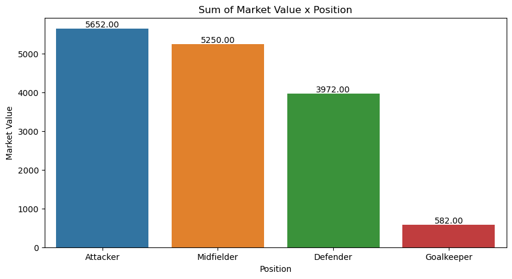

```python
#Visualizing for new categorized positions
plt.figure(figsize=(10, 5))
plt.title("Sum of Market Value x Position")
ax = sns.barplot(x="New_Position", y="Market value based on positions", data=position1)
for p in ax.patches:
    ax.annotate(format(p.get_height(), '.2f'),
                (p.get_x() + p.get_width() / 2., p.get_height()),
                ha = 'center', va = 'center',
                xytext = (0, 5),
                textcoords = 'offset points')

plt.xlabel("Position")
plt.ylabel("Market Value")
plt.show()
```

```python
position2=df.groupby(by="Position").Market_value.sum().reset_index(name="Market value based on positions")
position2.sort_values(by="Market value based on positions",ascending=False,inplace=True)
position2
```

|  | Position | Market value based on positions |
| --- | --- | --- |
| 2 | Centre-Back | 2521 |
| 1 | Central Midfield | 2401 |
| 3 | Centre-Forward | 2325 |
| 7 | Left Winger | 1601 |
| 10 | Right Winger | 1447 |
| 0 | Attacking Midfield | 1290 |
| 4 | Defensive Midfield | 1263 |
| 11 | Right-Back | 777 |
| 8 | Left-Back | 674 |
| 5 | Goalkeeper | 582 |
| 12 | Second Striker | 279 |
| 6 | Left Midfield | 213 |
| 9 | Right Midfield | 83 |

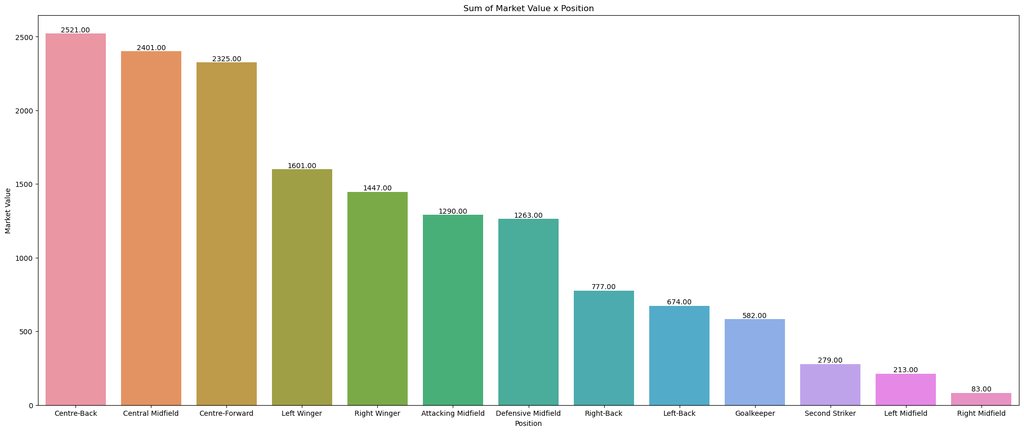

```python
#Visualing for the positions
plt.figure(figsize=(25, 10))
plt.title("Sum of Market Value x Position")
ax = sns.barplot(x="Position", y="Market value based on positions", data=position2)
for p in ax.patches:
    ax.annotate(format(p.get_height(), '.2f'),
                (p.get_x() + p.get_width() / 2., p.get_height()),
                ha = 'center', va = 'center',
                xytext = (0, 5),
                textcoords = 'offset points')

plt.xlabel("Position")
plt.ylabel("Market Value")
plt.show()
```

```python
y = df.groupby('New_Position').Market_value.mean().sort_values(ascending=False)
y
```

```
New_Position
Attacker      33.247059
Midfielder    31.626506
Goalkeeper    30.631579
Defender      28.782609
Name: Market_value, dtype: float64
```

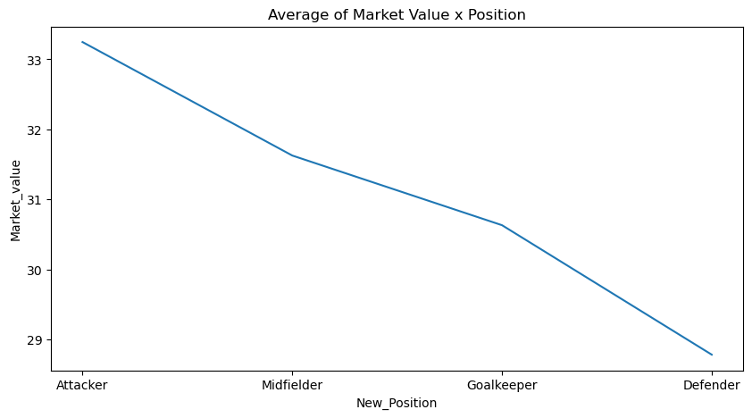

```python
# visualizing

plt.figure(figsize=(10,5))

plt.title("Average of Market Value x Position")

sns.lineplot(data=y)
```

```python
position2
```

|  | Position | Market value based on positions |
| --- | --- | --- |
| 2 | Centre-Back | 2521 |
| 1 | Central Midfield | 2401 |
| 3 | Centre-Forward | 2325 |
| 7 | Left Winger | 1601 |
| 10 | Right Winger | 1447 |
| 0 | Attacking Midfield | 1290 |
| 4 | Defensive Midfield | 1263 |
| 11 | Right-Back | 777 |
| 8 | Left-Back | 674 |
| 5 | Goalkeeper | 582 |
| 12 | Second Striker | 279 |
| 6 | Left Midfield | 213 |
| 9 | Right Midfield | 83 |

```python
df.groupby('Position').Market_value.agg(['max', 'min']).sort_values(by=['max', 'min'], ascending = False)
```

| Position | max | min |
| --- | --- | --- |
| Centre-Forward | 144 | 16 |
| Attacking Midfield | 90 | 18 |
| Left Winger | 90 | 16 |
| Right Winger | 90 | 16 |
| Central Midfield | 81 | 16 |
| Defensive Midfield | 81 | 16 |
| Centre-Back | 67 | 16 |
| Right-Back | 67 | 16 |
| Goalkeeper | 63 | 16 |
| Left-Back | 63 | 16 |
| Second Striker | 63 | 16 |
| Left Midfield | 58 | 16 |
| Right Midfield | 27 | 16 |

```python
c=df.groupby('Position').Market_value.sum().sort_values(ascending = False)
c
```

```
Position
Centre-Back           2521
Central Midfield      2401
Centre-Forward        2325
Left Winger           1601
Right Winger          1447
Attacking Midfield    1290
Defensive Midfield    1263
Right-Back             777
Left-Back              674
Goalkeeper             582
Second Striker         279
Left Midfield          213
Right Midfield          83
Name: Market_value, dtype: int32
```

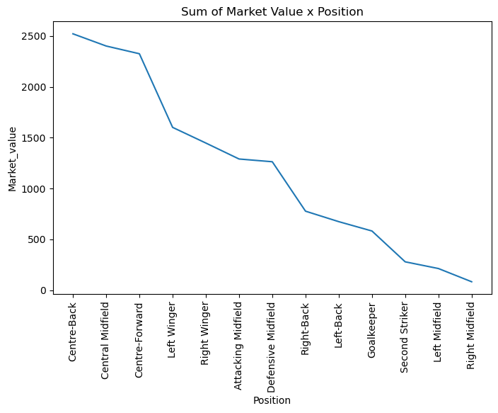

```python
# visualizing

plt.figure(figsize=(8,5))

plt.title("Sum of Market Value x Position")

plt.xticks(rotation=90)

sns.lineplot(data=c)
```

```python
df.groupby("Position").Market_value.mean().sort_values(ascending=False)
```

```
Position
Left Winger           35.577778
Second Striker        34.875000
Centre-Forward        33.695652
Attacking Midfield    33.076923
Central Midfield      32.445946
Defensive Midfield    30.804878
Left-Back             30.636364
Goalkeeper            30.631579
Right Winger          30.145833
Centre-Back           29.313953
Left Midfield         26.625000
Right-Back            25.900000
Right Midfield        20.750000
Name: Market_value, dtype: float64
```

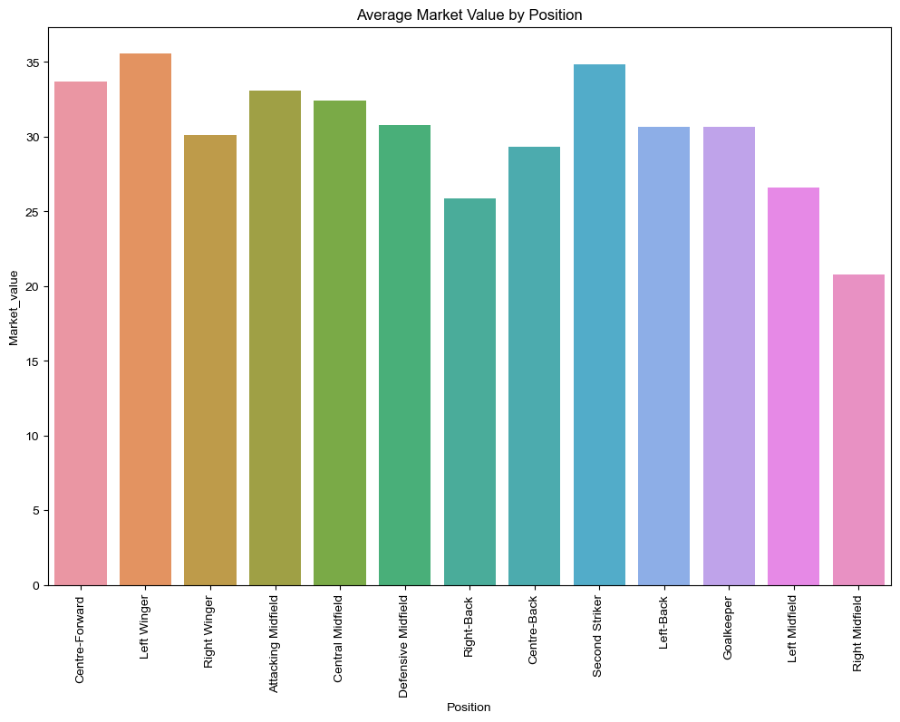

```python
plt.figure(figsize=(12, 8))
sns.barplot(data=df, x='Position', y='Market_value',errorbar=None)
plt.title('Average Market Value by Position')
sns.set_style("white")
plt.xticks(rotation=90)
plt.show()
```

### Insights

1.Analyzing by general positions, we notice that the dataset has a higher number of forwards, followed by midfielders and defenders. The goalkeepers appear in a smaller quantity.

2.We can also observe that forwards are more valued, followed by midfielders and defenders. Goalkeepers have a significantly lower total market value. However, when we look at the average, defenders are below goalkeepers.

3.Analyzing specific positions within forwards, midfielders, and defenders, we notice that we have a large number of center-backs, central midfielders, and center-forwards in the dataset. Due to the higher quantity, these positions also have the highest sum of market value.

However, when we consider the average, left-wingers, second strikers, and center-forwards have the highest value index.

## 4.2 Country

```python
df
```

|  | Name | Position | Age | Market_value | Country | Club | Matches | Goals | Own_goals | Assists | Yellow_cards | Second_yellow_cards | Red_cards | Substitute_in | Substitute_out | New_Position | Goals.per.game | Assists.per.game |
| --- | --- | --- | --- | --- | --- | --- | --- | --- | --- | --- | --- | --- | --- | --- | --- | --- | --- | --- |
| 0 | Kylian Mbappé | Centre-Forward | 22 | 144 | France | Paris Saint-Germain | 16 | 7 | 0 | 11 | 3 | 0 | 0 | 0 | 8 | Attacker | 0.44 | 0.69 |
| 1 | Erling Haaland | Centre-Forward | 21 | 135 | Norway | Borussia Dortmund | 10 | 13 | 0 | 4 | 1 | 0 | 0 | 0 | 1 | Attacker | 1.30 | 0.40 |
| 2 | Harry Kane | Centre-Forward | 28 | 108 | England | Tottenham Hotspur | 16 | 7 | 0 | 2 | 2 | 0 | 0 | 2 | 2 | Attacker | 0.44 | 0.12 |
| 3 | Jack Grealish | Left Winger | 26 | 90 | England | Manchester City | 15 | 2 | 0 | 3 | 1 | 0 | 0 | 2 | 8 | Attacker | 0.13 | 0.20 |
| 4 | Mohamed Salah | Right Winger | 29 | 90 | Egypt | Liverpool FC | 15 | 15 | 0 | 6 | 1 | 0 | 0 | 0 | 3 | Attacker | 1.00 | 0.40 |
| ... | ... | ... | ... | ... | ... | ... | ... | ... | ... | ... | ... | ... | ... | ... | ... | ... | ... | ... |
| 494 | Adam Armstrong | Centre-Forward | 24 | 16 | England | Southampton FC | 11 | 2 | 0 | 2 | 0 | 0 | 0 | 1 | 2 | Attacker | 0.18 | 0.18 |
| 496 | Ayoze Pérez | Second Striker | 28 | 16 | Spain | Leicester City | 8 | 1 | 0 | 3 | 0 | 0 | 1 | 2 | 5 | Attacker | 0.12 | 0.38 |
| 497 | Alex Meret | Goalkeeper | 24 | 16 | Italy | SSC Napoli | 5 | 0 | 0 | 0 | 0 | 0 | 0 | 0 | 0 | Goalkeeper | 0.00 | 0.00 |
| 498 | Duje Caleta-Car | Centre-Back | 25 | 16 | Croatia | Olympique Marseille | 8 | 0 | 0 | 0 | 2 | 0 | 0 | 0 | 2 | Defender | 0.00 | 0.00 |
| 499 | Aritz Elustondo | Centre-Back | 27 | 16 | Spain | Real Sociedad | 15 | 3 | 0 | 1 | 4 | 0 | 0 | 1 | 1 | Defender | 0.20 | 0.07 |

493 rows × 18 columns

```python
#number of players playing for different countries
df["Country"].value_counts()
```

```
England           67
France            56
Spain             52
Brazil            40
Germany           29
Portugal          25
Italy             25
Argentina         22
Netherlands       17
Belgium           14
Uruguay           10
Cote d'Ivoire      8
Croatia            8
Denmark            7
Nigeria            7
Colombia           7
Switzerland        6
Turkey             6
Austria            6
Senegal            6
Scotland           5
Poland             5
United States      5
Serbia             5
Algeria            4
Sweden             4
Morocco            4
Mexico             3
Norway             3
Ukraine            3
Japan              2
Mali               2
Albania            2
Zambia             2
Guinea             2
Canada             2
Burkina Faso       2
Czech Republic     2
Jamaica            1
Gabon              1
Wales              1
Venezuela          1
Georgia            1
Israel             1
The Gambia         1
Korea, South       1
Slovenia           1
Montenegro         1
Ghana              1
Iran               1
Cameroon           1
Slovakia           1
Egypt              1
Hungary            1
Russia             1
Peru               1
Name: Country, dtype: int64
```

```python
#Top 10 countries
country1=pd.DataFrame(df["Country"].value_counts().head(10))
country1.rename(columns={"Country":"Number of players"},inplace=True)
country1
```

|  | Number of players |
| --- | --- |
| England | 67 |
| France | 56 |
| Spain | 52 |
| Brazil | 40 |
| Germany | 29 |
| Portugal | 25 |
| Italy | 25 |
| Argentina | 22 |
| Netherlands | 17 |
| Belgium | 14 |

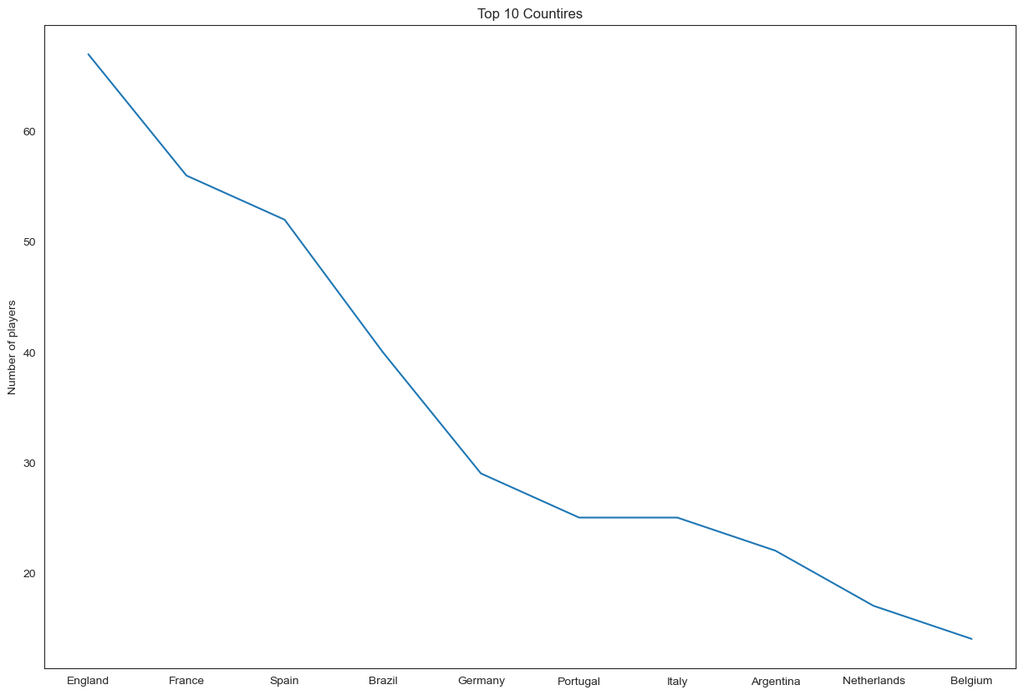

```python
#Visualizing top 10 countires
plt.figure(figsize=(15,10))
plt.title("Top 10 Countires")
sns.lineplot(data=country1["Number of players"])
```

```python
df.groupby('Country').Market_value.agg(['max', 'min']).sort_values(by=['max', 'min'], ascending = False).head(10)
```

| Country | max | min |
| --- | --- | --- |
| France | 144 | 16 |
| Norway | 135 | 16 |
| England | 108 | 16 |
| Egypt | 90 | 90 |
| Belgium | 90 | 16 |
| Brazil | 90 | 16 |
| Netherlands | 81 | 19 |
| Germany | 81 | 16 |
| Portugal | 81 | 16 |
| Korea, South | 76 | 76 |

```python
df.groupby('Country').Market_value.mean().sort_values(ascending = False).head(10)
```

```
Country
Egypt           90.000000
Korea, South    76.000000
Slovenia        63.000000
Norway          62.333333
Slovakia        54.000000
Canada          47.000000
Morocco         37.250000
Belgium         37.071429
Ghana           36.000000
Senegal         35.000000
Name: Market_value, dtype: float64
```

```python
selected_countries = ['Slovenia', 'Norway', 'Slovakia', 'Canada', 'Marocco', 'Belgium', 'Ghana', 'Senegal']
counts = df[df['Country'].isin(selected_countries)]['Country'].value_counts()
counts
```

```
Belgium     14
Senegal      6
Norway       3
Canada       2
Slovenia     1
Slovakia     1
Ghana        1
Name: Country, dtype: int64
```

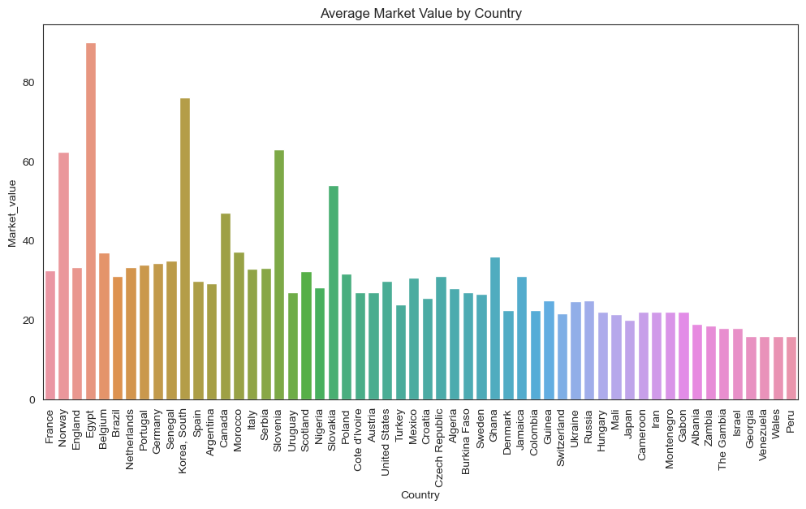

```python
# visualizing
plt.figure(figsize=(12, 6))
sns.barplot(data=df, x='Country', y='Market_value',errorbar=None)
plt.title('Average Market Value by Country')
plt.xticks(rotation=90)
plt.show()
```

### Insights

1.England has the highest number of players in the dataset, followed by France, Spain, Brazil, and Germany. These same five countries have the highest total market values due to having more players on the list.

2.France and Norway have the highest maximum value, as they have the two most valued players. Egypt has the same maximum and minimum value, along with the highest average value, because the country has only one player in the list (Salah).

3.Other countries have higher averages because they have few players in the database, such as South Korea, Norway, Slovakia, and Slovenia.

## 4.3 Age

```python
df.Age.value_counts()
```

```
24    83
25    52
26    51
23    44
27    41
28    41
21    36
22    36
29    35
30    24
20    14
19    13
31     8
18     6
33     3
32     2
34     1
36     1
17     1
16     1
Name: Age, dtype: int64
```

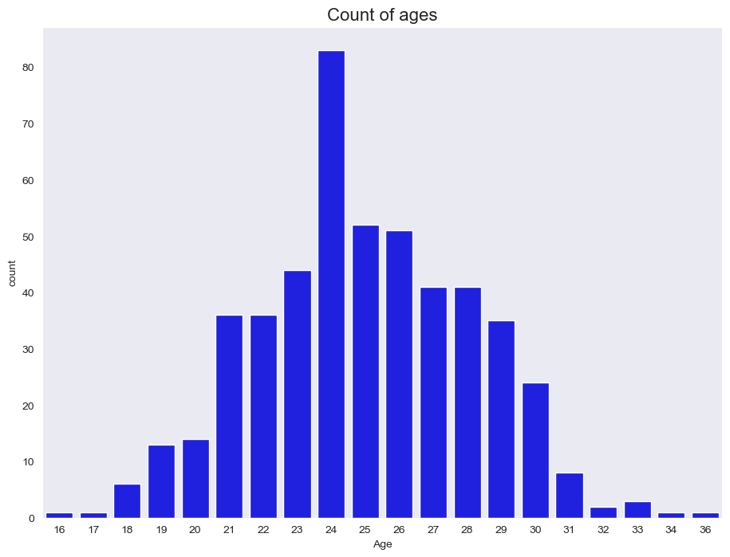

```python
plt.figure(figsize=(11,8))

sns.set_style("dark")

plt.title("Count of ages", fontsize=16)

plt.xlabel=("Age")

sns.countplot(data=df, x="Age", color='blue')
```

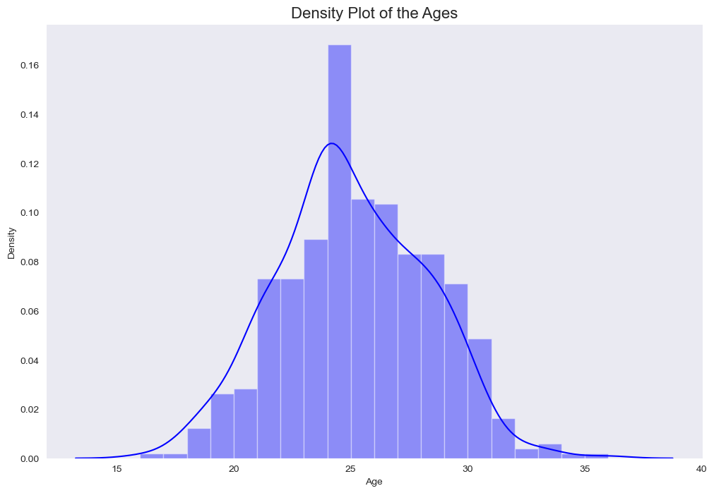

```python
plt.figure(figsize=(12, 8))
sns.distplot(df['Age'], hist=True, color='Blue')
plt.title("Density Plot of the Ages", fontsize=16)
```

```python
# age x market value sum

df.groupby('Age').Market_value.sum().sort_values(ascending=False).head(10)
```

```
Age
24    2526
26    1694
25    1386
28    1357
29    1350
22    1275
27    1245
23    1231
21    1154
30     729
Name: Market_value, dtype: int32
```

```python
# age x market value average

df.groupby('Age').Market_value.mean().sort_values(ascending=False).head(10)
```

```
Age
34    72.000000
18    46.666667
36    40.000000
29    38.571429
22    35.416667
26    33.215686
28    33.097561
21    32.055556
33    31.333333
24    30.433735
Name: Market_value, dtype: float64
```

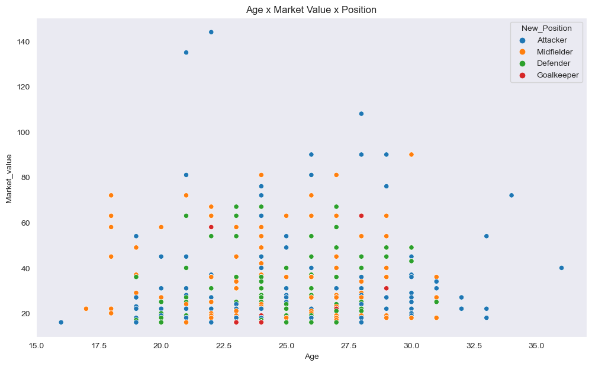

```python
plt.figure(figsize=(12,7))

plt.title("Age x Market Value x Position")

sns.scatterplot(data=df, x='Age', y='Market_value', hue='New_Position')

sns.set_style("darkgrid")
```

### Insights

1.Most of the players in the dataset are in the age range of 20 to 30 years.

## 4.4 Clubs

```python
df.Club.unique()
```

```
array(['Paris Saint-Germain', 'Borussia Dortmund', 'Tottenham Hotspur',
       'Manchester City', 'Liverpool FC', 'Chelsea FC',
       'Manchester United', 'FC Barcelona', 'Bayern Munich',
       'Inter Milan', 'Atlético de Madrid', 'West Ham United',
       'Real Sociedad', 'Juventus FC', 'SS Lazio', 'Real Madrid',
       'Bayer 04 Leverkusen', 'Arsenal FC', 'Sevilla FC', 'SSC Napoli',
       'Leicester City', 'Everton FC', 'AC Milan', 'Villarreal CF',
       'ACF Fiorentina', 'RB Leipzig', 'AS Roma', 'Crystal Palace',
       'Wolverhampton Wanderers', 'Valencia CF', 'Leeds United',
       'LOSC Lille', 'Aston Villa', 'Olympique Lyon', 'OGC Nice',
       'AS Monaco', 'Atalanta BC', 'US Sassuolo', 'Torino FC',
       'Ajax Amsterdam', 'Brentford FC', 'Southampton FC',
       'Newcastle United', 'VfL Wolfsburg', 'FC Porto',
       'Olympique Marseille', 'Eintracht Frankfurt',
       'Borussia Mönchengladbach', 'Watford FC', 'Stade Rennais FC',
       'Club Brugge KV', 'Sporting CP', 'Brighton & Hove Albion',
       'Dynamo Kyiv', 'Athletic Bilbao', 'Real Betis Balompié',
       'Zenit St. Petersburg', 'Burnley FC', 'SL Benfica',
       'TSG 1899 Hoffenheim', 'Norwich City', 'PSV Eindhoven',
       'VfB Stuttgart', 'KRC Genk', 'Club Atlético Vélez Sarsfield',
       'Club Atlético River Plate', 'FC Metz', 'UC Sampdoria',
       'Red Bull Salzburg', 'Bologna FC 1909', 'Shakhtar Donetsk',
       'Cagliari Calcio', 'Getafe CF', 'Al-Rayyan SC', 'Rubin Kazan',
       'Feyenoord Rotterdam', 'RCD Espanyol Barcelona', 'UD Almería',
       'Sheffield United', 'Celta de Vigo'], dtype=object)
```

```python
df.Club.nunique()
```

```
80
```

```python
top_20_clubs = df.Club.value_counts().head(20)
top_20_clubs
```

```
Manchester United          19
Manchester City            18
Paris Saint-Germain        16
Tottenham Hotspur          16
Chelsea FC                 16
Real Madrid                16
Liverpool FC               15
Arsenal FC                 15
Atlético de Madrid         15
RB Leipzig                 15
Bayern Munich              14
Juventus FC                13
AC Milan                   13
Everton FC                 13
Atalanta BC                12
Aston Villa                11
Leicester City             11
FC Barcelona               11
Borussia Dortmund          11
Wolverhampton Wanderers    10
Name: Club, dtype: int64
```

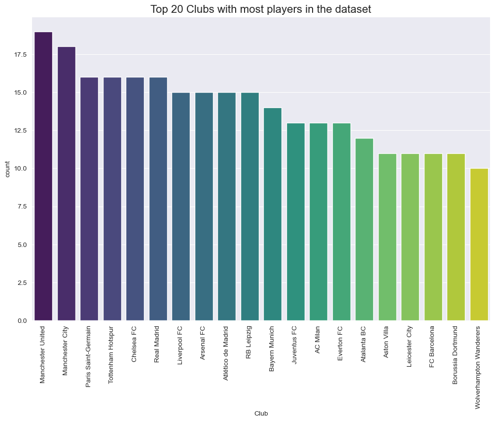

```python
# visualizing

plt.figure(figsize=(12, 8))

plt.title("Top 20 Clubs with most players in the dataset", fontsize=16)

sns.countplot(data=df, x='Club', order=top_20_clubs.index, palette='viridis')

plt.xticks(rotation=90)

plt.show()
```

```python
df.groupby('Club').Market_value.sum().sort_values(ascending = False).nlargest(20)
```

```
Club
Manchester City        937
Paris Saint-Germain    772
Manchester United      754
Chelsea FC             704
Bayern Munich          683
Liverpool FC           677
Atlético de Madrid     615
Real Madrid            590
Tottenham Hotspur      530
FC Barcelona           448
Juventus FC            447
Borussia Dortmund      422
Arsenal FC             403
RB Leipzig             375
Inter Milan            373
AC Milan               354
SSC Napoli             351
Leicester City         349
Everton FC             316
Aston Villa            284
Name: Market_value, dtype: int32
```

```python
top_20_clubs_value = df.groupby('Club').Market_value.mean().sort_values(ascending = False).nlargest(20)
top_20_clubs_value
```

```
Club
Manchester City        52.055556
Bayern Munich          48.785714
Paris Saint-Germain    48.250000
Inter Milan            46.625000
Liverpool FC           45.133333
Chelsea FC             44.000000
Atlético de Madrid     41.000000
FC Barcelona           40.727273
Manchester United      39.684211
Borussia Dortmund      38.363636
Real Madrid            36.875000
SSC Napoli             35.100000
Juventus FC            34.384615
Sevilla FC             33.666667
Tottenham Hotspur      33.125000
SS Lazio               33.000000
Bayer 04 Leverkusen    32.500000
Leicester City         31.727273
West Ham United        31.714286
Torino FC              31.000000
Name: Market_value, dtype: float64
```

```
No artists with labels found to put in legend.  Note that artists whose label start with an underscore are ignored when legend() is called with no argument.
```

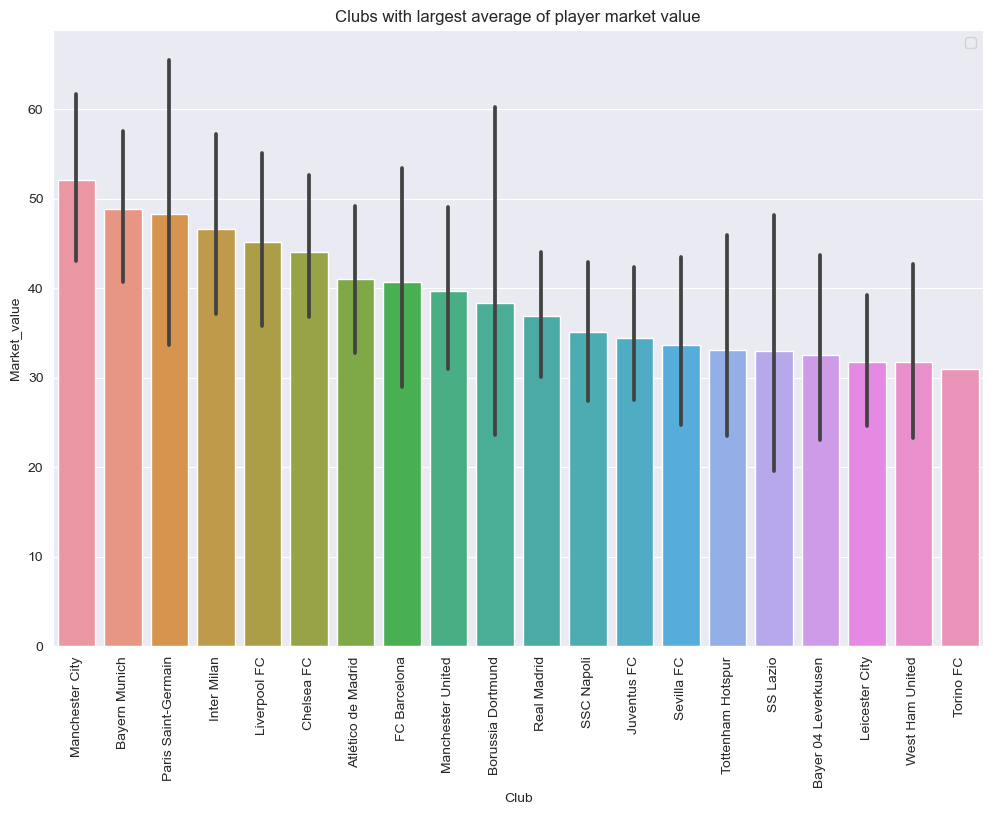

```python
# visualizing

plt.figure(figsize=(12,8))

plt.title("Clubs with largest average of player market value")

sns.barplot(data=df, x='Club', y='Market_value', order=top_20_clubs_value.index)

sns.set_style("dark")

plt.xticks(rotation=90)

plt.legend()
```

### Insights

1.As we have seen, there are multiple clubs in the dataset. The ones with the highest number of players are as follows: Manchester United (19 players), Manchester City (18 players), Paris Saint-Germain (16 players), Tottenham Hotspur (16 players), Chelsea FC (16 players), and Real Madrid (16 players).

2.Manchester City leads in the total market value sum, followed by Paris Saint-Germain, Manchester United, Chelsea FC, and Bayern Munich.

3.When we observe the average market value per club, we notice that Manchester City, Bayern Munich, Paris Saint-Germain, Inter Milan, and Liverpool have the highest values, indicating how valuable the players of these teams are.

## 4.5 Players

```python
#Number of players
df.Name.nunique()
```

```
493
```

```python
#Top 10 players based on Market Value
top_10 = df.sort_values(ascending = False, by='Market_value').head(10)
top_10
```

|  | Name | Position | Age | Market_value | Country | Club | Matches | Goals | Own_goals | Assists | Yellow_cards | Second_yellow_cards | Red_cards | Substitute_in | Substitute_out | New_Position | Goals.per.game | Assists.per.game |
| --- | --- | --- | --- | --- | --- | --- | --- | --- | --- | --- | --- | --- | --- | --- | --- | --- | --- | --- |
| 0 | Kylian Mbappé | Centre-Forward | 22 | 144 | France | Paris Saint-Germain | 16 | 7 | 0 | 11 | 3 | 0 | 0 | 0 | 8 | Attacker | 0.44 | 0.69 |
| 1 | Erling Haaland | Centre-Forward | 21 | 135 | Norway | Borussia Dortmund | 10 | 13 | 0 | 4 | 1 | 0 | 0 | 0 | 1 | Attacker | 1.30 | 0.40 |
| 2 | Harry Kane | Centre-Forward | 28 | 108 | England | Tottenham Hotspur | 16 | 7 | 0 | 2 | 2 | 0 | 0 | 2 | 2 | Attacker | 0.44 | 0.12 |
| 4 | Mohamed Salah | Right Winger | 29 | 90 | Egypt | Liverpool FC | 15 | 15 | 0 | 6 | 1 | 0 | 0 | 0 | 3 | Attacker | 1.00 | 0.40 |
| 5 | Romelu Lukaku | Centre-Forward | 28 | 90 | Belgium | Chelsea FC | 11 | 4 | 0 | 1 | 0 | 0 | 0 | 1 | 2 | Attacker | 0.36 | 0.09 |
| 6 | Kevin De Bruyne | Attacking Midfield | 30 | 90 | Belgium | Manchester City | 14 | 3 | 0 | 1 | 1 | 0 | 0 | 4 | 6 | Midfielder | 0.21 | 0.07 |
| 7 | Neymar | Left Winger | 29 | 90 | Brazil | Paris Saint-Germain | 11 | 3 | 0 | 3 | 3 | 0 | 0 | 0 | 3 | Attacker | 0.27 | 0.27 |
| 3 | Jack Grealish | Left Winger | 26 | 90 | England | Manchester City | 15 | 2 | 0 | 3 | 1 | 0 | 0 | 2 | 8 | Attacker | 0.13 | 0.20 |
| 8 | Jadon Sancho | Left Winger | 21 | 81 | England | Manchester United | 13 | 0 | 0 | 0 | 0 | 0 | 0 | 7 | 5 | Attacker | 0.00 | 0.00 |
| 9 | Frenkie de Jong | Central Midfield | 24 | 81 | Netherlands | FC Barcelona | 13 | 0 | 0 | 2 | 2 | 1 | 0 | 0 | 2 | Midfielder | 0.00 | 0.15 |

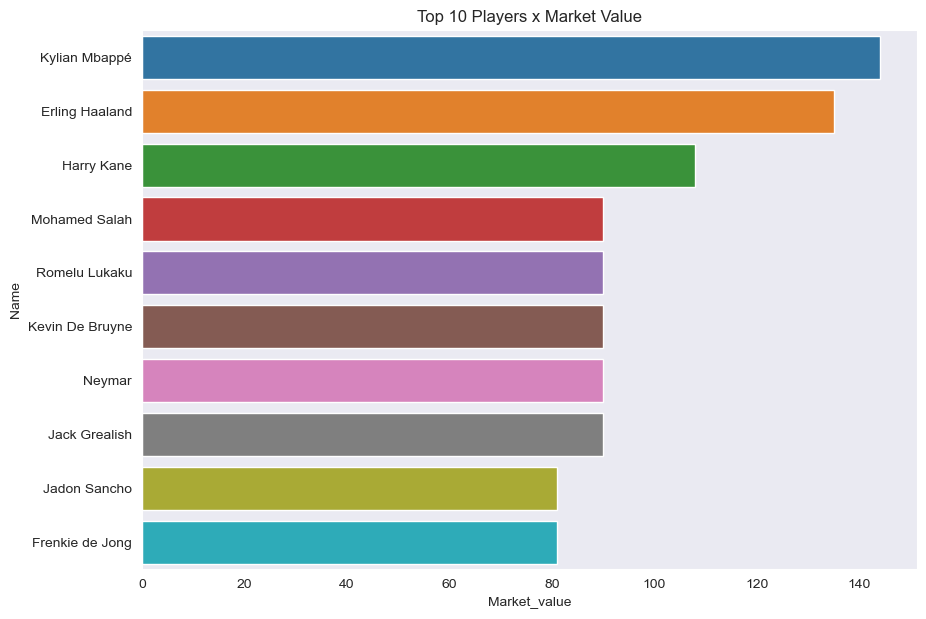

```python
#visualizing

plt.figure(figsize=(10,7))

plt.title("Top 10 Players x Market Value")

sns.barplot(data=top_10, y="Name", x="Market_value")

sns.set_style("darkgrid")
```

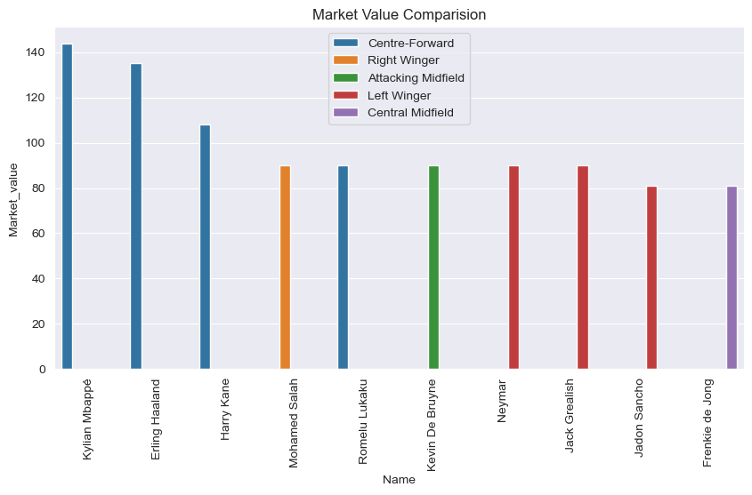

```python
# visualizing

plt.figure(figsize=(10,5))

plt.title("Market Value Comparision")

sns.barplot(x='Name', y='Market_value', hue='Position', data=top_10)

plt.xticks(rotation=90)

plt.legend()
```

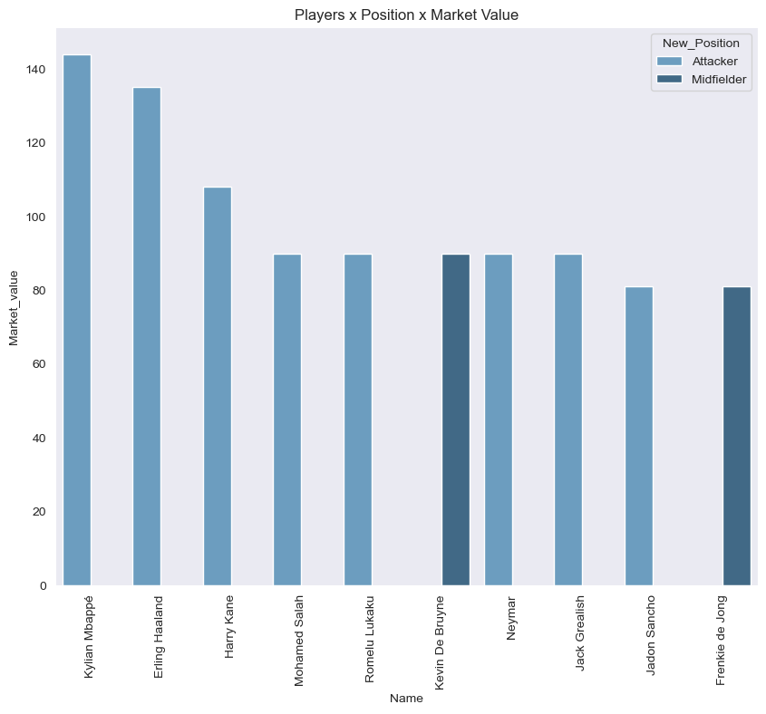

```python
plt.figure(figsize=(10,8))

plt.title("Players x Position x Market Value")

plt.xticks(rotation=90)

sns.set_style("dark")

sns.barplot(x='Name', y='Market_value', hue='New_Position', data=top_10, palette='Blues_d')
```

```python
df.groupby(['Name', 'Club']).Market_value.sum().sort_values(ascending = False).nlargest(10)
```

```
Name             Club
Kylian Mbappé    Paris Saint-Germain    144
Erling Haaland   Borussia Dortmund      135
Harry Kane       Tottenham Hotspur      108
Mohamed Salah    Liverpool FC            90
Kevin De Bruyne  Manchester City         90
Jack Grealish    Manchester City         90
Neymar           Paris Saint-Germain     90
Romelu Lukaku    Chelsea FC              90
Raheem Sterling  Manchester City         81
Joshua Kimmich   Bayern Munich           81
Name: Market_value, dtype: int32
```

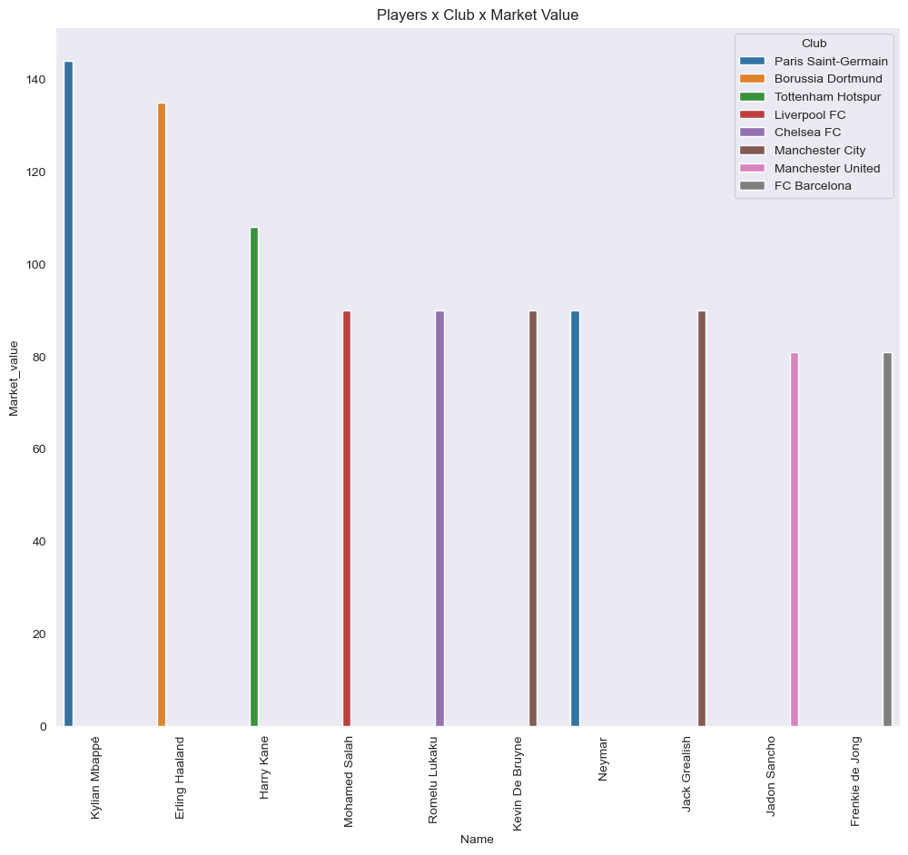

```python
# visualizing

plt.figure(figsize=(12,10))

plt.title("Players x Club x Market Value")

plt.xticks(rotation=90)

sns.set_style("dark")

sns.barplot(x='Name', y='Market_value', hue='Club', data=top_10)
```

### Insights

1.I analyzed the top 10 players with the highest market value in the dataset. As we can see, Kylian Mbappé, Erling Haaland, Harry Kane, Mohamed Salah, and Lukaku are leading the list.

2.Among these 10 players, 8 are forwards, while 2 are midfielders. Additionally, we have 4 Centre-Forwards, 3 Left-Wingers, 1 Right-Winger, 1 Attacking Midfield, and 1 Center-Midfielder.

3.Analyzing by club, we have two players from Manchester City and two from Paris Saint-Germain among the top 10 most valued players. The other clubs have one player each. The clubs are as follows: Borussia Dortmund, Tottenham Hotspur, Liverpool FC, Chelsea FC, Manchester United, and FC Barcelona.

# 5. comparing the two most valuable players based on various parameters.

The two most valuable players are Kylian Mbappé and Erling Haaland

```python
df.groupby(['Name', 'Club']).Market_value.sum().sort_values(ascending = False).nlargest(2)
```

```
Name            Club
Kylian Mbappé   Paris Saint-Germain    144
Erling Haaland  Borussia Dortmund      135
Name: Market_value, dtype: int32
```

```python
top_2 = df[df['Name'].isin(['Erling Haaland', 'Kylian Mbappé'])]
top_2
```

|  | Name | Position | Age | Market_value | Country | Club | Matches | Goals | Own_goals | Assists | Yellow_cards | Second_yellow_cards | Red_cards | Substitute_in | Substitute_out | New_Position | Goals.per.game | Assists.per.game |
| --- | --- | --- | --- | --- | --- | --- | --- | --- | --- | --- | --- | --- | --- | --- | --- | --- | --- | --- |
| 0 | Kylian Mbappé | Centre-Forward | 22 | 144 | France | Paris Saint-Germain | 16 | 7 | 0 | 11 | 3 | 0 | 0 | 0 | 8 | Attacker | 0.44 | 0.69 |
| 1 | Erling Haaland | Centre-Forward | 21 | 135 | Norway | Borussia Dortmund | 10 | 13 | 0 | 4 | 1 | 0 | 0 | 0 | 1 | Attacker | 1.30 | 0.40 |

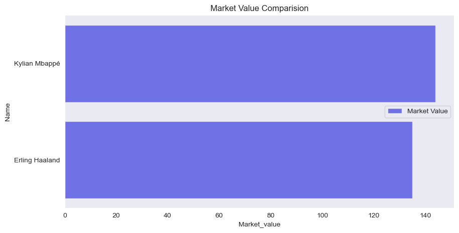

```python
# visualizing the Market value of two players

plt.figure(figsize=(10,5))

plt.title("Market Value Comparision")

sns.set_style("darkgrid")

sns.barplot(y='Name', x='Market_value', data=top_2, color='blue', alpha=0.6, label='Market Value')

plt.legend()
```

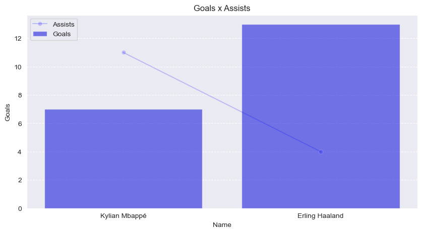

```python
# visualizing the goals and assists of two players

plt.figure(figsize=(10,5))

plt.title("Goals x Assists")

sns.barplot(x='Name', y='Goals', data=top_2, color='blue', alpha=0.6, label='Goals')

sns.lineplot(data=top_2['Assists'], color='blue', alpha=0.2, marker='o', label='Assists')

plt.grid(True, axis='y', linestyle='--', alpha=1.0)

sns.set_style("dark")

plt.legend()

plt.show()
```

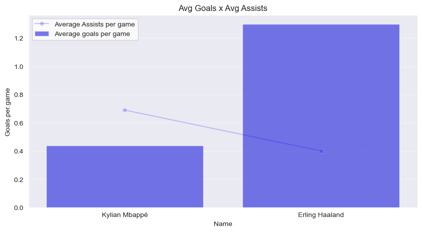

```python
# visualizing the Goals per game and assists per game of two players

plt.figure(figsize=(10,5))

plt.title("Avg Goals x Avg Assists")

sns.barplot(x='Name', y='Goals.per.game', data=top_2, color='blue', alpha=0.6, label='Average goals per game')

sns.lineplot(data=top_2['Assists.per.game'], color='blue', alpha=0.2, marker='o', label='Average Assists per game')

plt.grid(True, axis='y', linestyle='--', alpha=0.7)

sns.set_style("white")

plt.legend()

plt.show()
```

### Insights

1.We noticed that Kylian Mbappé is ahead of Erling Haaland in terms of market value.

2.When comparing goals and assists, we observed two opposite dynamics: Mbappé had more assists, while Haaland scored more goals. This same trend repeated for the average goals per match and average assists per match.